# Bellabeat Case Study

Using Google Sheets, SQL & R Table of Contents:

### 1.Company Summary

#### 1.1 About Bellabeat

Urška Sršen and Sando Mur founded Bellabeat, a high-tech company that manufactures health-focused smart products for women. Collecting data on activity, sleep, stress, and reproductive health has allowed Bellabeat to empower women with knowledge about their own health and habits. Since it was founded in 2013, Bellabeat has grown rapidly and quickly positioned itself as a tech-driven wellness company for women. By 2016, Bellabeat had opened offices around the world and launched multiple products. Bellabeat products became available through a growing number of online retailers in addition to their own e-commerce channel on their website. Bellabeat invests year-round in Google Search, maintaining active Facebook and Instagram pages, and consistently engages consumers on Twitter(X). Additionally, Bellabeat runs video ads on Youtube and display ads on the Google Display Network to support campaigns around key marketing dates.

#### 1.2 Company Products

- **Bellabeat app**: The Bellabeat app provides users with health data related to their activity, sleep, stress, menstrual cycle, and mindfulness habits.
- **Leaf**:Bellabeat’s classic wellness tracker can be worn as a bracelet, necklace, or clip.
- **Time**:This wellness watch combines the timeless look of a classic timepiece with smart technology to track user activity, sleep, and stress.
- **Spring**: This is a water bottle that tracks daily water intake using smart technology to ensure that you are appropriately hydrated throughout the day.
- **Bellabeat membership**: Bellabeat also offers a subscription-based membership program for users. Membership gives users 24/7 access to fully personalized guidance on nutrition, activity, sleep, health, beauty, and mindfulness based on their lifestyle and goals.

### 2.ASK

#### 2.1 Business Task

To analyze non-Bellabeat smart fitness devices usage data, identify trends in smart fitness devices usage, how these trends can be applied to Bellabeat’s customers and how they cacn help influence Bellabeat’s marketing strategy.

#### 2.2 Key Stakeholders

- **Urška Sršen**: Bellabeat’s cofounder and Chief Creative Officer
- **Sando Mur**: Mathematician and Bellabeat’s cofounder, key member of the Bellabeat executive team
- **Bellabeat’s marketing analytics team**: A team of data analysts

### 3.PREPARE

#### 3.1 Data Summary

The data source used for this case study is [FitBit Fitness Tracker Data](https://www.kaggle.com/datasets/arashnic/fitbit). This dataset was downloaded from Kaggle where it was uploaded by Möbius. According to the dataset information submitted on Zenodo.org,“this dataset was generated by respondents to a distributed survey via Amazon Mechanical Turk between 03.12.2016 – 05.12.2016.Thirty eligible Fitbit users consented to the submission of personal tracker data, including minute-level output for physical activity, heart rate, and sleep monitoring.” Additionally, “Variation between output represents use of different types of Fitbit trackers and individual tracking behaviors / preferences.”

#### 3.2 Accessibility & Usage of Data

The dataset was published by Möbius to Kaggle.com under the CC0: Public Domain Creative Common License – waiving all rights to the work and allowing for the dataset to be copies, modified, distributed and performed without asking for permission. Möbius cited the dataset from Zendo: Furberg, Robert; Brinton, Julia; Keating, Michael ; Ortiz, Alexa

#### 3.3 Data Limitations & Integrity

The **FitBit Fitness Tracker Data** was collected in 2016 making the datasets outdated for current trend analysis. Additionally, while the data initially states a time range of 03-12-2016 to 05-12-2016, after data verification, the data collected was only during a 31 day period (04-12-2016 to 05-12-2016). Since the data only included instances over a 31 day period, the time-frame for a more insightful analysis is relatively small.

Lastly, the sample size itself could create a sample bias. While a sample size of 30 (our data later shows a sample size of 33) will hold up within the CLT theorem, a larger sample size will be more representative of the population and would increase the confidence interval. Additionally, since there were no demographic information collected it will be hard to see if we have a true representation of a national or global population. This lack of demographic information will also limit recommendations on the target audience (including gender, location, age and job status) and where to market them. Considering that Bellabeat is primarily targeted to women and individuals who menstruate, having demographics would have bolstered any recommendations after analysis.

### 4.PROCESS

#### 4.1 Datasets Selected

- dailyActivity_merged
- hourlyCalories_merged
- hourlyIntensities_merged
- hourlySteps_merged
- sleepDay_merged
- weightLogInfo_merged

#### 4.2 Data Cleaning Using Google Sheets

Following steps were taken with each dataset for cleaning:

- Performed remove duplicates function using data clean-up tool to remove all duplicate data
- Performed trim whitespace function using data clean-up tool to remove any leading, trailing and repeated spaces in data
- Used the Create Filter tool to check for null or missing values
- Formatted all numerical data into number format with either no decimals or upto 2 decimals
- Used DATEVALUE() & TIMEVALUE() function to convert and split the date-time string to separate date and time columns respectively for effecient analysis
- Formatted all date data into [MM/DD/YY] date format for consistency
- Formatted all time data into [hh:mm:ss], 24 hour format for consistency
- Used LEN() function to check for inconsistent id entries
- Renamed all columns in lowercase & added underscore between label names for consistent naming

After the cleaning process was finished, only 3 rows of duplicate data was found in sleepDay_merged dataset and removed after which 410 unique rows remained.

#### 4.3 Next Steps

After cleaning the data, I decided to work with SQL to analyze & aggregate the data. Why SQL? SQL allows powerful data manipulation through queries and is a globally recognized standard language for multiple relational databases. It is a must have skillset for any data analyst across all regions, so I’m hoping to showcase my querying skillset here.

With that said Excel & R would have worked for cleaning and analysis as well. [NICOLE LYNN S.](https://www.kaggle.com/code/nicolelynns/bellabeat-case-study-excel-sql-tableau) has some good examples of cleaning this data with Excel and [MACARENA LACASA](https://www.kaggle.com/code/macarenalacasa/capstone-case-study-bellabeat) has some good examples of analysis with R.

### 5.ANALYZE & SHARE

`Note:Before we move onto the analyze part, remember we will aggregate & summarize our data using BigQuery and for visualizations we will be using R`

`First we need to set up our environment for displaying our outputs & visualizations`

```
library(tidyverse)    # For data manipulation & analysis
library(kableExtra)   # For viewing tables in an awesome way!
library(scales)   # For transforming numbers in percentage
library(highcharter) # Cool and interactive graphs
library(RColorBrewer)  # Pallete colors
```

#### 5.1 Dataset Verification

For dataset verification I decided to use BIGQUERY(SQL).

##### 5.1.1 SQL Dataset Upload

Uploaded the following clean datasets into BIGQUERY(SQL) under the project bellabeat-case-study-474418 :

`Note: The links below display the first five rows of the dataset`

**dailyActivity_merged**

Table 1: Daily Activity

| id | date | total_steps | total_distance | very_active_distance | moderately_active_distance | light_active_distance | sedentary_active_distance | very_active_minutes | fairly_active_minutes | light_active_minutes | sedentary_minutes | calories |
| --- | --- | --- | --- | --- | --- | --- | --- | --- | --- | --- | --- | --- |
| 1503960366 | 2016/04/12 | 13162 | 8.50 | 1.88 | 0.55 | 6.06 | 0 | 25 | 13 | 328 | 728 | 1985 |
| 1503960366 | 2016/04/13 | 10735 | 6.97 | 1.57 | 0.69 | 4.71 | 0 | 21 | 19 | 217 | 776 | 1797 |
| 1503960366 | 2016/04/14 | 10460 | 6.74 | 2.44 | 0.40 | 3.91 | 0 | 30 | 11 | 181 | 1218 | 1776 |
| 1503960366 | 2016/04/15 | 9762 | 6.28 | 2.14 | 1.26 | 2.83 | 0 | 29 | 34 | 209 | 726 | 1745 |
| 1503960366 | 2016/04/16 | 12669 | 8.16 | 2.71 | 0.41 | 5.04 | 0 | 36 | 10 | 221 | 773 | 1863 |

**hourlyCalories_merged**

Table 2: Daily Hourly Calories

| id | date | time | calories |
| --- | --- | --- | --- |
| 1503960366 | 4/12/2016 | 00:00:00 | 81 |
| 1503960366 | 4/12/2016 | 01:00:00 | 61 |
| 1503960366 | 4/12/2016 | 02:00:00 | 59 |
| 1503960366 | 4/12/2016 | 03:00:00 | 47 |
| 1503960366 | 4/12/2016 | 04:00:00 | 48 |

**hourlyIntensities_merged**

Table 3: Daily Hourly Intensities

| Id | date | time | total_intensity | average_intensity |
| --- | --- | --- | --- | --- |
| 1503960366 | 4/12/2016 | 00:00:00 | 20 | 0.33 |
| 1503960366 | 4/12/2016 | 01:00:00 | 8 | 0.13 |
| 1503960366 | 4/12/2016 | 02:00:00 | 7 | 0.12 |
| 1503960366 | 4/12/2016 | 03:00:00 | 0 | 0.00 |
| 1503960366 | 4/12/2016 | 04:00:00 | 0 | 0.00 |

**hourlySteps_merged**

Table 4: Daily Hourly Steps

| id | date | time | step_total |
| --- | --- | --- | --- |
| 1503960366 | 12/04/2016 | 00:00:00 | 373 |
| 1503960366 | 12/04/2016 | 01:00:00 | 160 |
| 1503960366 | 12/04/2016 | 02:00:00 | 151 |
| 1503960366 | 12/04/2016 | 03:00:00 | 0 |
| 1503960366 | 12/04/2016 | 04:00:00 | 0 |

**sleepDay_merged**

Table 5: Daily sleep

| id | date | time | total_sleep_records | total_minutes_sleep | total_time_in_bed |
| --- | --- | --- | --- | --- | --- |
| 1503960366 | 4/12/2016 | 00:00:00 | 1 | 327 | 346 |
| 1503960366 | 4/13/2016 | 00:00:00 | 2 | 384 | 407 |
| 1503960366 | 4/15/2016 | 00:00:00 | 1 | 412 | 442 |
| 1503960366 | 4/16/2016 | 00:00:00 | 2 | 340 | 367 |
| 1503960366 | 4/17/2016 | 00:00:00 | 1 | 700 | 712 |

**weightLogInfo_merged**

Table 6: Weight Info

| Id | date | time | weight_kg | weight_pounds | bmi | is_manual_report | log_id |
| --- | --- | --- | --- | --- | --- | --- | --- |
| 1503960366 | 5/2/2016 | 23:59:59 | 52.6 | 115.96 | 22.65 | TRUE | 1.462234e+12 |
| 1503960366 | 5/3/2016 | 23:59:59 | 52.6 | 115.96 | 22.65 | TRUE | 1.462320e+12 |
| 1927972279 | 4/13/2016 | 01:08:52 | 133.5 | 294.32 | 47.54 | FALSE | 1.460510e+12 |
| 2873212765 | 4/21/2016 | 23:59:59 | 56.7 | 125.00 | 21.45 | TRUE | 1.461283e+12 |
| 2873212765 | 5/12/2016 | 23:59:59 | 57.3 | 126.32 | 21.69 | TRUE | 1.463098e+12 |

##### 5.1.2 Removing Some Extra Variables

If you want to view the original dataset click [here](https://www.kaggle.com/datasets/arashnic/fitbit).

##### 5.1.3 User Verification By Id

Checked for # of participants by counting number of distinct Ids in each dataset.

```
SELECT COUNT (DISTINCT id) AS Total_Ids
FROM `bellabeat-case-study-474418.Fitness_data.dailyAcitvities_merged`
```

I repeated the SQL query above with each dataset (changing the FROM clause each time) and received these results:

- dailyActivity_merged - 33
- sleepDay_merged - 24
- hourlyCalories_merged - 33
- hourlyIntensities_merged - 33
- hourlySteps_merged - 33
- weightLogInfo_merged - 8

WeightLogInfo_merged dataset does not include enough data to move forward with analysis. Therefore this dataset will not be used.

#### 5.2 Insights

##### 5.2.1 Users Based on Daily Activity Minutes

First,I wanted to see the types of users based on their activity minutes.For this I created three types of users:

- **Very Active** - >120 minutes/day
- **Moderately Active** - 120-90 minutes/day
- **Lightly Active** - < 90 minutes/day

```
WITH user_activity AS (
    SELECT
        id AS User_Id,
        AVG(very_active_minutes + fairly_active_minutes + light_active_minutes) AS Avg_Active_Minutes,
        CASE
            WHEN AVG(very_active_minutes + fairly_active_minutes + light_active_minutes) > 120 THEN 'Very Active'
            WHEN AVG(very_active_minutes + fairly_active_minutes + light_active_minutes) BETWEEN 90 AND 120 THEN 'Moderately Active'
            ELSE 'Lightly Active'
        END AS activity_type
    FROM
        `bellabeat-case-study-474418.Fitness_data.dailyAcitvities_merged`
    GROUP BY
        id
)
SELECT
    activity_type,
    COUNT(*) AS num_users
FROM
    user_activity
GROUP BY
    activity_type
ORDER BY
    CASE activity_type
        WHEN 'Very Active' THEN 1
        WHEN 'Moderately Active' THEN 2
        WHEN 'Lightly Active' THEN 3
    END;
```

RESULTS

| activity_type | num_users |
| --- | --- |
| Very Active | 27 |
| Moderately Active | 3 |
| Lightly Active | 3 |

[interactive chart not shown]

The results showed that there were:

- 27 - Very Active Users
- 3 - Moderately Active Users
- 3 - Lightly Active Users

We can see that most of our users are very active participants.

##### 5.2.2 User Activity Minutes Per Week

The **CDC** recommends 150 minutes of physical activity each week https://www.cdc.gov/physicalactivity/basics/adults/index.htm.

So I wanted to see the average of the sum of minutes of Very Active Minutes and Fairly Active Minutes to see if each distinct Id was hitting those CDC activity recommendations.I wont be using the Lightly Active Minutes data in order to count for only the actual physical activity performed.

Since our data spans from(04-12-2016 to 05-12-2016).We will be checking for each week separately.

**WEEK 1: (‘04-12-2016’ AND ‘04-18-2016’)**

```
WITH Weekly_Activity AS (
    SELECT
        id AS User_Id,
        SUM(very_active_minutes + fairly_active_minutes) AS Total_Active_Minutes
    FROM
        `bellabeat-case-study-474418.Fitness_data.dailyAcitvities_merged`
    WHERE
        date BETWEEN '2016-04-12' AND '2016-04-18'
    GROUP BY
        id
)
SELECT
    CASE
        WHEN Total_Active_Minutes >= 150 THEN 'Meet CDC Recommendations'
        ELSE 'Do Not Meet CDC Recommendations'
    END AS CDC_Category,
    COUNT(*) AS Num_Users
FROM
    Weekly_Activity
GROUP BY
    CDC_Category
ORDER BY
    CDC_Category DESC;
```

RESULTS

| CDC_Category | Num_Users |
| --- | --- |
| Meet CDC Recommendations | 17 |
| Do Not Meet CDC Recommendations | 16 |

**WEEK 2: (‘04-19-2016’ AND ‘04-25-2016’)**

```
WITH Weekly_Activity AS (
    SELECT
        id AS User_Id,
        SUM(very_active_minutes + fairly_active_minutes) AS Total_Active_Minutes
    FROM
        `bellabeat-case-study-474418.Fitness_data.dailyAcitvities_merged`
    WHERE
        date BETWEEN '2016-04-19' AND '2016-04-25'
    GROUP BY
        id
)
SELECT
    CASE
        WHEN Total_Active_Minutes >= 150 THEN 'Meet CDC Recommendations'
        ELSE 'Do Not Meet CDC Recommendations'
    END AS CDC_Category,
    COUNT(*) AS Num_Users
FROM
    Weekly_Activity
GROUP BY
    CDC_Category
ORDER BY
    CDC_Category DESC;
```

RESULTS

| CDC_Category | Num_Users |
| --- | --- |
| Meet CDC Recommendations | 18 |
| Do Not Meet CDC Recommendations | 14 |

**WEEK 3: (‘04-26-2016’ AND ‘05-02-2016’)**

```
WITH Weekly_Activity AS (
    SELECT
        id AS User_Id,
        SUM(very_active_minutes + fairly_active_minutes) AS Total_Active_Minutes
    FROM
        `bellabeat-case-study-474418.Fitness_data.dailyAcitvities_merged`
    WHERE
        date BETWEEN '2016-04-26' AND '2016-05-02'
    GROUP BY
        id
)
SELECT
    CASE
        WHEN Total_Active_Minutes >= 150 THEN 'Meet CDC Recommendations'
        ELSE 'Do Not Meet CDC Recommendations'
    END AS CDC_Category,
    COUNT(*) AS Num_Users
FROM
    Weekly_Activity
GROUP BY
    CDC_Category
ORDER BY
    CDC_Category DESC;
```

RESULTS

| CDC_Category | Num_Users |
| --- | --- |
| Meet CDC Recommendations | 19 |
| Do Not Meet CDC Recommendations | 13 |

`Note: For week 4 i took all the remaining days of the month into account`

```
WITH Weekly_Activity AS (
    SELECT
        id AS User_Id,
        SUM(very_active_minutes + fairly_active_minutes) AS Total_Active_Minutes
    FROM
        `bellabeat-case-study-474418.Fitness_data.dailyAcitvities_merged`
    WHERE
        date BETWEEN '2016-05-03' AND '2016-05-12'
    GROUP BY
        id
)
SELECT
    CASE
        WHEN Total_Active_Minutes >= 150 THEN 'Meet CDC Recommendations'
        ELSE 'Do Not Meet CDC Recommendations'
    END AS CDC_Category,
    COUNT(*) AS Num_Users
FROM
    Weekly_Activity
GROUP BY
    CDC_Category
ORDER BY
    CDC_Category DESC;
```

RESULTS

| CDC_Category | Num_Users |
| --- | --- |
| Meet CDC Recommendations | 19 |
| Do Not Meet CDC Recommendations | 10 |

- WEEK 1: Out of 33 users, 17 met the CDC Recommendations and 16 did not.
- WEEK 2: Out of 33 users, 18 met the CDC Recommendations, 14 did not and 1 did not have data from this time frame.
- WEEK 3: Out of 33 users, 19 met the CDC Recommendations, 13 did not and 1 did not have data from this time frame.
- WEEK 4: Out of 33 users, 19 met the CDC Recommendations, 10 did not and 4 did not have data from this time frame.

We can see the decrease in user participation during the last weeks of the data collected.Now, we know that most of our participants are Very Active Users but not all of them are meeting the required CDC recommendations of 150 minutes of physical activity per week.

With that said, I saw no significant changes to length of activity each week and the overall data collection time frame is pretty small. While the summary of the dataset being used (FitBit Fitness Tracker Data) stated that data was collected from 2016-03-12 through 2016-05-12, there was no data tracked for most users until 2016-04-12. This indicates that there is really only 1 month of data to work with. This isn’t a significant amount of time to see if habits have changed from the beginning of using the wearable to when the data collection ended.

##### 5.2.3 Average Daily Activity Patterns Across the Week

Now, I wanted to dive deeper into my dataset to find the average minutes of each activity type (very, fairly, and lightly active minutes) for each day of the week.So that i can understand more clearly the pattern for the activity types the users perform for each weekday.

```
SELECT
    FORMAT_DATE('%A', DATE(date)) AS Day_Of_Week,
    AVG(very_active_minutes) AS Avg_Very_Active_Minutes,
    AVG(fairly_active_minutes) AS Avg_Fairly_Active_Minutes,
    AVG(light_active_minutes) AS Avg_Light_Active_Minutes
FROM
    `bellabeat-case-study-474418.Fitness_data.dailyAcitvities_merged`
GROUP BY
    Day_Of_Week
ORDER BY
    CASE Day_Of_Week
        WHEN 'Monday' THEN 1
        WHEN 'Tuesday' THEN 2
        WHEN 'Wednesday' THEN 3
        WHEN 'Thursday' THEN 4
        WHEN 'Friday' THEN 5
        WHEN 'Saturday' THEN 6
        WHEN 'Sunday' THEN 7
    END;
```

RESULTS

| Day_Of_Week | Avg_Very_Active_Minutes | Avg_Fairly_Active_Minutes | Avg_Light_Active_Minutes |
| --- | --- | --- | --- |
| Monday | 23.11 | 14.00 | 192.06 |
| Tuesday | 23.26 | 14.53 | 199.97 |
| Wednesday | 20.78 | 13.10 | 189.85 |
| Thursday | 19.68 | 12.12 | 187.98 |
| Friday | 20.06 | 12.11 | 204.20 |
| Saturday | 22.10 | 15.33 | 208.83 |
| Sunday | 19.98 | 14.53 | 173.98 |

[interactive chart not shown]

The Results Showed the Following:

##### 5.2.4 Average Steps By Weekday

Next, I wanted to take a look at average steps by day to see if there were any patterns that users followed.

`NOTE: I arranged the days in ascending order of steps to indentify trends`

```
SELECT
    FORMAT_DATE('%A', DATE(date)) AS Day_Of_Week,
    ROUND(AVG(total_steps), 2) AS Avg_Steps
FROM
    `bellabeat-case-study-474418.Fitness_data.dailyAcitvities_merged`
GROUP BY
    Day_Of_Week
ORDER BY
    Avg_Steps ;
```

RESULTS

| Day_Of_Week | Avg_Steps |
| --- | --- |
| Sunday | 6933.23 |
| Friday | 7448.23 |
| Thursday | 7507.99 |
| Wednesday | 7559.37 |
| Monday | 7780.87 |
| Saturday | 8219.26 |
| Tuesday | 8233.34 |

[interactive chart not shown]

The Results Show the Following:

##### 5.2.5 Average Steps By Hour

Now , I wanted to dive deeper into the average steps by hours of the day to figure out at what time of the day users mostly performed active step count.

```
SELECT
  EXTRACT(HOUR FROM time) AS Hour_Of_Day,
  ROUND(AVG(step_total), 2) AS Avg_Steps
FROM
  `bellabeat-case-study-474418.Fitness_data.hourlySteps_merged`
GROUP BY
  Hour_Of_Day
ORDER BY
  Hour_Of_Day ;
```

RESULTS

| Hour_Of_Day | Avg_Steps |
| --- | --- |
| 0 | 42.19 |
| 1 | 23.10 |
| 2 | 17.11 |
| 3 | 6.43 |
| 4 | 12.70 |
| 5 | 43.87 |
| 6 | 178.51 |
| 7 | 306.05 |
| 8 | 427.54 |
| 9 | 433.30 |
| 10 | 481.67 |
| 11 | 456.89 |
| 12 | 548.64 |
| 13 | 537.70 |
| 14 | 540.51 |
| 15 | 406.32 |
| 16 | 496.85 |
| 17 | 550.23 |
| 18 | 599.17 |
| 19 | 583.39 |
| 20 | 353.91 |
| 21 | 308.14 |
| 22 | 237.99 |
| 23 | 122.13 |

[interactive chart not shown]

The Results Show the Following Observations:

- Activity is almost zero between 12 AM–5 AM, indicating sleep hours.
- Steps start rising sharply from 6 AM, marking the start of daily routines.
- Morning activity peaks around 8–9 AM with moderate movement.
- The highest activity occurs between 12 PM–6 PM, especially at 6 PM (599 steps).
- Step counts remain consistently high through the afternoon period (12–5 PM).
- Activity starts declining after 7 PM, showing evening wind-down.
- Steps drop significantly after 9 PM, reaching low values again by 11 PM.

Overall,the hourly step data reveals a distinct daily rhythm, with minimal movement during late-night hours and peak activity in the late afternoon. Most users begin their day’s movement around 6 AM, maintain steady activity through midday, and reach their highest step counts around 5–6 PM before winding down at night. This pattern reflects typical routines — rest at night, rising activity with the day’s progress, and peak engagement in the evening — highlighting opportunities for targeted fitness interventions during morning and late-afternoon hours.

##### 5.2.6 Calories Burned By Steps Taken

Next , I was curious to know about what the data would show for the amount of calories burned for the total steps taken considering all the users to verify my hypothesis that higher the step count would lead to greater calories burned.

`Note: For this analysis the data we will be using is too huge to display hence we will move on to visualization using R directly.`

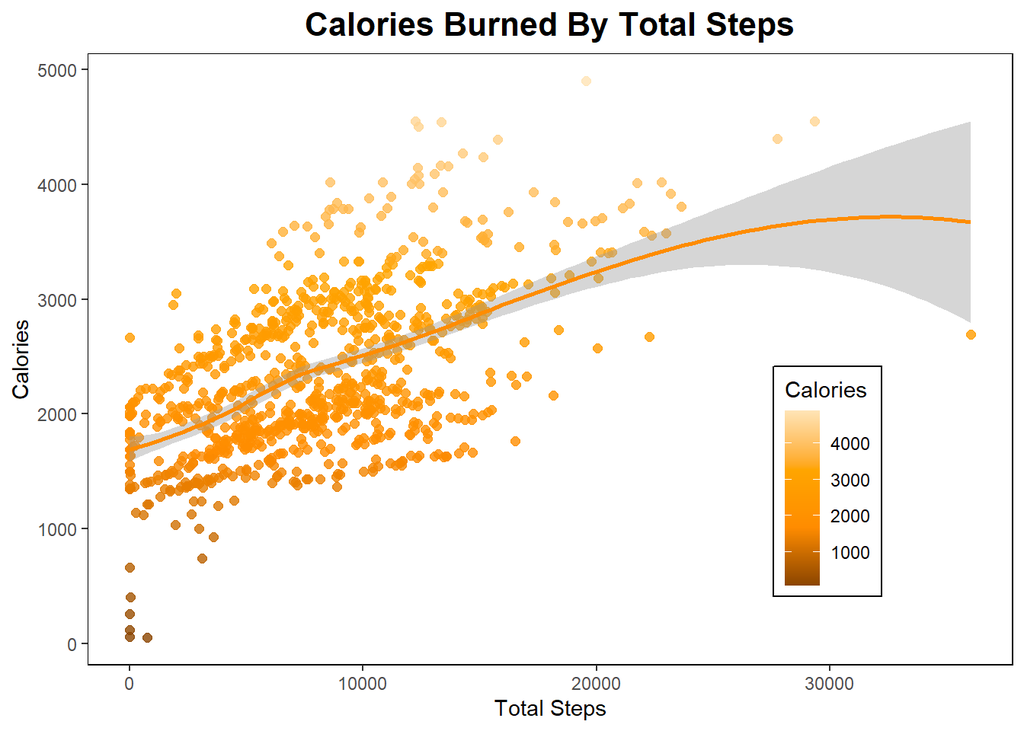

The Visualization shows the following:

Overall analysis of the dataset shows a clear positive relationship between total steps and calories burned across users. This confirms my hypothesis that higher physical activity, measured as step count, leads to greater calorie expenditure. This insight reinforces the importance of daily movement for health and can guide personalized activity recommendations.

##### 5.2.7 Deeper Look Into Sleep

Next, I wanted to take a deeper look into the sleep patterns of the users. First I wanted to look at the average, minimum, and maximum sleep per user.

```
SELECT
    id AS user_id,
    ROUND(AVG(total_minutes_sleep), 2) AS avg_sleep_minutes,
    ROUND(AVG(total_minutes_sleep)/60, 2) AS avg_sleep_hours,
    ROUND(MIN(total_minutes_sleep), 2) AS min_sleep_minutes,
    ROUND(MAX(total_minutes_sleep), 2) AS max_sleep_minutes
FROM `bellabeat-case-study-474418.Fitness_data.sleepDay_merged`
GROUP BY id
```

RESULTS

| user_id | avg_sleep_minutes | avg_sleep_hours | min_sleep_minutes | max_sleep_minutes |
| --- | --- | --- | --- | --- |
| 1503960366 | 360.04 | 6.00 | 245 | 700 |
| 1644430081 | 294.00 | 4.90 | 119 | 796 |
| 1844505072 | 652.00 | 10.87 | 590 | 722 |
| 1927972279 | 417.00 | 6.95 | 166 | 750 |
| 2026352035 | 506.18 | 8.44 | 357 | 573 |
| 2320127002 | 61.00 | 1.02 | 61 | 61 |
| 2347167796 | 446.80 | 7.45 | 374 | 556 |
| 3977333714 | 293.64 | 4.89 | 152 | 424 |
| 4020332650 | 349.38 | 5.82 | 77 | 501 |
| 4319703577 | 476.65 | 7.94 | 59 | 692 |
| 4388161847 | 400.17 | 6.67 | 62 | 619 |
| 4445114986 | 385.18 | 6.42 | 98 | 502 |
| 4558609924 | 127.60 | 2.13 | 103 | 171 |
| 4702921684 | 417.48 | 6.96 | 253 | 591 |
| 5553957443 | 463.48 | 7.72 | 322 | 775 |
| 5577150313 | 432.00 | 7.20 | 74 | 603 |
| 6117666160 | 478.78 | 7.98 | 336 | 658 |
| 6775888955 | 349.67 | 5.83 | 235 | 423 |
| 6962181067 | 448.00 | 7.47 | 298 | 630 |
| 7007744171 | 68.50 | 1.14 | 58 | 79 |
| 7086361926 | 453.13 | 7.55 | 322 | 681 |
| 8053475328 | 297.00 | 4.95 | 74 | 486 |
| 8378563200 | 445.13 | 7.42 | 323 | 611 |
| 8792009665 | 435.67 | 7.26 | 339 | 531 |

Now I wanted to take a closer look at the Average Sleep Minutes pattern of the users to see if they were averaging the recommended 7hrs(420 minutes) of sleep, for this I prepared the following visualization:

[interactive chart not shown]

The visualization shows the following:

The visualization highlights that while about half the users meet or exceed the recommended 7 hours of sleep, the other half fall significantly short, revealing uneven sleep quality and inconsistency across the user group. These insights help identify users needing sleep hygiene improvements, and also highlights potential data quality issues where sleep logs are incomplete due to the small sampling size of our dataset used.

##### 5.2.8 Total Steps By Total Sleep

Lastly, before i moved onto ACT and Recommendations , I was curious to know whether the users who were getting enough or the recommended amount(7hrs) of sleep were tracking higher step count than users who did not meet the recommended amount of sleep.

```
SELECT
    dailyActivity.id,
    ROUND(AVG(dailyActivity.total_steps), 2) AS avg_steps,
    ROUND(AVG(sleepDay.total_minutes_sleep), 2) AS avg_sleep_minutes
FROM
    `bellabeat-case-study-474418.Fitness_data.dailyAcitvities_merged` AS dailyActivity
INNER JOIN
    `bellabeat-case-study-474418.Fitness_data.sleepDay_merged` AS sleepDay
ON
    dailyActivity.id = sleepDay.id
GROUP BY
    dailyActivity.id;
```

RESULTS

| id | avg_steps | avg_sleep_minutes |
| --- | --- | --- |
| 1644430081 | 7282.97 | 294.00 |
| 2347167796 | 9519.67 | 446.80 |
| 3977333714 | 10984.57 | 293.64 |
| 4319703577 | 7268.84 | 476.65 |
| 4388161847 | 10813.94 | 400.17 |
| 4702921684 | 8572.06 | 417.48 |
| 5577150313 | 8304.43 | 432.00 |
| 6775888955 | 2620.48 | 349.67 |
| 6962181067 | 9794.81 | 448.00 |
| 7007744171 | 11323.42 | 68.50 |
| 7086361926 | 9371.77 | 453.12 |
| 8792009665 | 1853.72 | 435.67 |
| 1844505072 | 2580.06 | 652.00 |
| 1927972279 | 916.13 | 417.00 |
| 2026352035 | 5566.87 | 506.18 |
| 2320127002 | 4716.87 | 61.00 |
| 4020332650 | 2267.23 | 349.38 |
| 4445114986 | 4796.55 | 385.18 |
| 4558609924 | 7685.13 | 127.60 |
| 5553957443 | 8612.58 | 463.48 |
| 6117666160 | 7046.71 | 478.78 |
| 8053475328 | 14763.29 | 297.00 |
| 8378563200 | 8717.71 | 445.13 |
| 1503960366 | 12520.63 | 360.04 |

For this I prepared the following visualization:

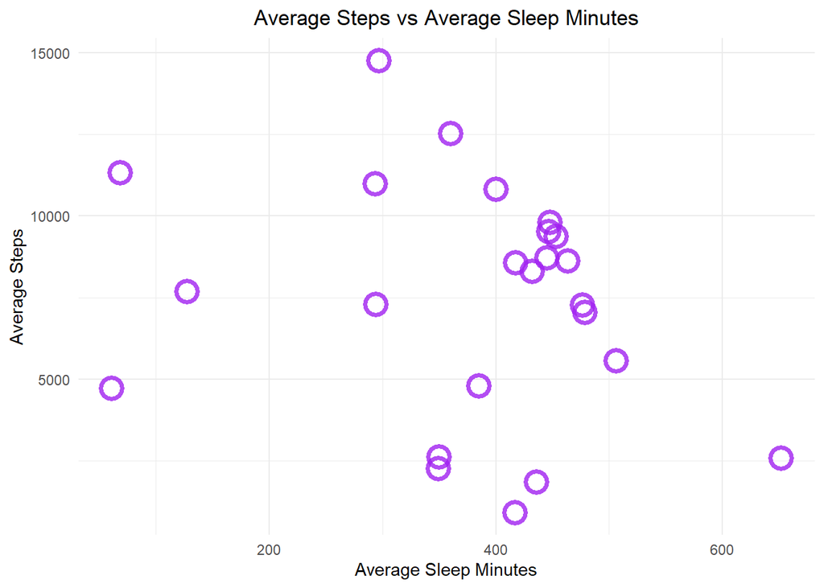

The Visualization shows the following:

- Users who get enough sleep (≥ 420 minutes) tend to have moderate average steps, but there are exceptions with some extremely high or low steps.
- Users who sleep less than 7 hours show higher step counts in some cases, particularly outliers like 14763 and 12520 steps.
- Overall, sleep alone doesn’t strictly predict higher steps — some high-step users sleep less than recommended, while some users who sleep more have lower activity.
- This indicates that other factors (age, lifestyle, or motivation) likely influence step counts alongside sleep.

Overall, the average daily steps and sleep minutes of 24 users revealed no clear pattern suggesting that meeting the recommended 7 hours of sleep directly leads to higher step counts. While some well-rested users exhibited moderate to high activity, some users with less than the recommended sleep achieved the highest step counts. Conversely, a few users with excessive sleep showed minimal activity. These findings suggest that while adequate sleep is essential for health, step count is more strongly influenced by lifestyle factors, habits, or personal motivation rather than sleep duration alone. For interventions aiming to increase daily physical activity, sleep duration should be considered alongside behavioral and environmental factors rather than as a sole predictor.

### 6.ACT

##### 6.1 Conclusion:

Bellabeat is a data-driven wellness technology company that designs smart devices and apps focused on women’s health and well-being. Their products — such as the Leaf wellness tracker, Time smart watch, and Bellabeat app — empower women to better understand their activity, sleep, stress, and overall lifestyle patterns. The goal of this analysis was to explore non-Bellabeat smart device usage data (FitBit dataset) to identify behavioral trends that can help Bellabeat enhance its marketing strategies and product engagement.

The dataset reveals that most users are active but struggle with consistency and balanced routines across sleep and activity. Despite a healthy portion of very active users, many still fail to maintain regular moderate-to-vigorous exercise. This shows potential for behavioral guidance, motivational prompts, and habit-forming engagement tools — areas where Bellabeat can add significant value.

By leveraging these insights, Bellabeat can strengthen its ecosystem — connecting women’s lifestyle data (activity, rest, stress, menstrual cycle) into actionable feedback loops that promote holistic wellness rather than focusing solely on fitness metrics.

##### 6.2 Marketing Recommendations:

**1.Personalized Motivation and Goal Setting**

- Use behavior-based insights to build AI-driven daily reminders or activity nudges when users are less active.
- Create personalized challenges (e.g., “5K Step Boost Mondays” or “Evening Energy Challenge”) that align with users’ most active times (12 PM–6 PM).

**2.Promote Holistic Wellness, Not Just Steps**

- Position Bellabeat as a women-first wellness platform — combining activity, sleep, and stress tracking into one narrative.
- Market wellness as a balance between movement, rest, and recovery — reflecting real user data showing inconsistency in both exercise and sleep.

**3.Timing-Based Engagement**

- Send motivational push notifications or guided session prompts during morning ramp-up (6–8 AM) and evening peak (5–6 PM) when users are most active.
- Introduce “Smart Breaks” during midday hours to encourage light movement during workdays.

**4.Address Sleep Irregularities**

- Launch in-app sleep wellness tips and wind-down reminders to help users who fall short of 7 hours.
- Use machine learning to detect sleep irregularities and suggest actionable improvements.

**5.Target the ‘Active but Inconsistent’ Segment**

- Design campaigns aimed at users who show high potential but irregular engagement (e.g., weekend-only exercisers).
- Use case-based storytelling in marketing materials (e.g., “The Busy Professional”, “The Weekend Warrior”) to highlight relatable user personas.

**6.Data-Driven Product Differentiation**

- Emphasize how Bellabeat integrates women’s physiological and lifestyle data (including menstrual cycles and stress) — features missing in most mainstream fitness trackers.
- Highlight that Bellabeat doesn’t just count steps — it interprets patterns to guide smarter wellness decisions.

##### 6.3 Next Steps

The analysis shows that while most users are active, consistency and balance between activity and rest remain key challenges. Bellabeat can use these insights to position itself as a holistic women’s wellness brand, focusing on personalized motivation, healthy routines, and smart habit formation.

By turning behavioral data into actionable guidance, Bellabeat can help users achieve sustainable health goals and strengthen engagement with its ecosystem.

- Segment users based on activity and sleep patterns to tailor marketing and in-app experiences.
- Predict inactivity trends using behavioral data for timely motivational prompts.
- Correlate activity, sleep, and stress data to offer personalized health insights.
- Collect longer-term data to evaluate lifestyle improvements over time.

Through data-driven personalization and proactive engagement, Bellabeat can empower women to take control of their wellness journey and reinforce its leadership in the smart fitness market.